# Attention is all you need - Transformer 논문 요약

### 실습

#### 뉴스그룹데이터 (sklearn)

```python
import pandas as pd
from sklearn.datasets import fetch_20newsgroups
dataset = fetch_20newsgroups(shuffle=True, random_state=1, remove=('headers', 'footers', 'quotes'))
documents = dataset.data
len(documents)
```

```
Downloading 20news dataset. This may take a few minutes.
Downloading dataset from https://ndownloader.figshare.com/files/5975967 (14 MB)
```

```
11314
```

```python
documents[1]
```

```
"\n\n\n\n\n\n\nYeah, do you expect people to read the FAQ, etc. and actually accept hard\natheism?  No, you need a little leap of faith, Jimmy.  Your logic runs out\nof steam!\n\n\n\n\n\n\n\nJim,\n\nSorry I can't pity you, Jim.  And I'm sorry that you have these feelings of\ndenial about the faith y…
```

```python
# 뉴스그룹 데이터가 가지고 있는 20개의 카테고리
print(dataset.target_names)
print(len(dataset.target_names))
```

```
['alt.atheism', 'comp.graphics', 'comp.os.ms-windows.misc', 'comp.sys.ibm.pc.hardware', 'comp.sys.mac.hardware', 'comp.windows.x', 'misc.forsale', 'rec.autos', 'rec.motorcycles', 'rec.sport.baseball', 'rec.sport.hockey', 'sci.crypt', 'sci.electronics', 'sci.med', 'sci.space', 'soc.religion.christian…
20
```

#### 텍스트 전처리

```python
news_df = pd.DataFrame({'document':documents})
# 특수 문자 제거
news_df['clean_doc'] = news_df['document'].str.replace("[^a-zA-Z]", " ")
# 길이가 3이하인 단어는 제거 (길이가 짧은 단어 제거)
news_df['clean_doc'] = news_df['clean_doc'].apply(lambda x: ' '.join([w for w in x.split() if len(w)>3]))
# 전체 단어에 대한 소문자 변환
news_df['clean_doc'] = news_df['clean_doc'].apply(lambda x: x.lower())
```

```python
news_df['clean_doc'][1]
```

```
'yeah expect people read actually accept hard atheism need little leap faith jimmy your logic runs steam sorry pity sorry that have these feelings denial about faith need well just pretend that will happily ever after anyway maybe start newsgroup atheist hard bummin much forget your flintstone chewa…
```

```python
import nltk
nltk.download('stopwords')
from nltk.corpus import stopwords
stop_words = stopwords.words('english') # NLTK로부터 불용어를 받아옵니다.
tokenized_doc = news_df['clean_doc'].apply(lambda x: x.split()) # 토큰화
tokenized_doc = tokenized_doc.apply(lambda x: [item for item in x if item not in stop_words])
# 불용어를 제거합니다.
```

```python
print(tokenized_doc[1])
```

```
['yeah', 'expect', 'people', 'read', 'actually', 'accept', 'hard', 'atheism', 'need', 'little', 'leap', 'faith', 'jimmy', 'logic', 'runs', 'steam', 'sorry', 'pity', 'sorry', 'feelings', 'denial', 'faith', 'need', 'well', 'pretend', 'happily', 'ever', 'anyway', 'maybe', 'start', 'newsgroup', 'atheist…
```

#### TF-IDF 행렬 만들기

- TF-IDF 벡터라이저는 기본적으로 토큰화가 되어있지 않은 텍스트 데이터를 사용함.
- 그렇기에 역토큰화 작업부터 진행

```python
# 역토큰화 (토큰화 작업을 역으로 되돌림)
detokenized_doc = []
for i in range(len(news_df)):
    t = ' '.join(tokenized_doc[i])
    detokenized_doc.append(t)

news_df['clean_doc'] = detokenized_doc
```

```python
news_df['clean_doc'][1]
```

```
'yeah expect people read actually accept hard atheism need little leap faith jimmy logic runs steam sorry pity sorry feelings denial faith need well pretend happily ever anyway maybe start newsgroup atheist hard bummin much forget flintstone chewables bake timmons'
```

```python
from sklearn.feature_extraction.text import TfidfVectorizer

vectorizer = TfidfVectorizer(stop_words='english',
                             max_features= 1000, # 상위 1,000개의 단어를 보존
                             max_df = 0.5,
                             smooth_idf=True)

X = vectorizer.fit_transform(news_df['clean_doc'])
X.shape # TF-IDF 행렬의 크기 확인
```

```
(11314, 1000)
```

#### 토픽모델링(Topic Modeling)

- TF-IDF 행렬을 절단된 SVD로 차원축소.

```python
from sklearn.decomposition import TruncatedSVD
svd_model = TruncatedSVD(n_components=20, algorithm='randomized', n_iter=100, random_state=122)
svd_model.fit(X)
len(svd_model.components_)
```

```
20
```

```python
np.shape(svd_model.components_) # svd_model.components_ : VT
```

```
(20, 1000)
```

```python
terms = vectorizer.get_feature_names() # 단어 집합. 1,000개의 단어가 저장됨.

# (20, 1000) 행렬에서 가장 값이 큰 5개의 값을 찾아서 단어로 출력함.
def get_topics(components, feature_names, n=5):
    for idx, topic in enumerate(components):
        print("Topic %d:" % (idx+1), [(feature_names[i], topic[i].round(5)) for i in topic.argsort()[:-n - 1:-1]])
get_topics(svd_model.components_,terms)
```

```
Topic 1: [('like', 0.21386), ('know', 0.20046), ('people', 0.19293), ('think', 0.17805), ('good', 0.15128)]
Topic 2: [('thanks', 0.32888), ('windows', 0.29088), ('card', 0.18069), ('drive', 0.17455), ('mail', 0.15111)]
Topic 3: [('game', 0.37064), ('team', 0.32443), ('year', 0.28154), ('games', 0.2537), ('season', 0.18419)]
Topic 4: [('drive', 0.53324), ('scsi', 0.20165), ('hard', 0.15628), ('disk', 0.15578), ('card', 0.13994)]
Topic 5: [('windows', 0.40399), ('file', 0.25436), ('window', 0.18044), ('files', 0.16078), ('program', 0.13894)]
Topic 6: [('chip', 0.16114), ('government', 0.16009), ('mail', 0.15625), ('space', 0.1507), ('information', 0.13562)]
Topic 7: [('like', 0.67086), ('bike', 0.14236), ('chip', 0.11169), ('know', 0.11139), ('sounds', 0.10371)]
Topic 8: [('card', 0.46633), ('video', 0.22137), ('sale', 0.21266), ('monitor', 0.15463), ('offer', 0.14643)]
Topic 9: [('know', 0.46047), ('card', 0.33605), ('chip', 0.17558), ('government', 0.1522), ('video', 0.14356)]
Topic 10: [('good', 0.42756), ('know', 0.23039), ('time', 0.1882), ('bike', 0.11406), ('jesus', 0.09027)]
Topic 11: [('think', 0.78469), ('chip', 0.10899), ('good', 0.10635), ('thanks', 0.09123), ('clipper', 0.07946)]
Topic 12: [('thanks', 0.36824), ('good', 0.22729), ('right', 0.21559), ('bike', 0.21037), ('problem', 0.20894)]
Topic 13: [('good', 0.36212), ('people', 0.33985), ('windows', 0.28385), ('know', 0.26232), ('file', 0.18422)]
Topic 14: [('space', 0.39946), ('think', 0.23258), ('know', 0.18074), ('nasa', 0.15174), ('problem', 0.12957)]
Topic 15: [('space', 0.31613), ('good', 0.3094), ('card', 0.22603), ('people', 0.17476), ('time', 0.14496)]
Topic 16: [('people', 0.48156), ('problem', 0.19961), ('window', 0.15281), ('time', 0.14664), ('game', 0.12871)]
Topic 17: [('time', 0.34465), ('bike', 0.27303), ('right', 0.25557), ('windows', 0.1997), ('file', 0.19118)]
Topic 18: [('time', 0.5973), ('problem', 0.15504), ('file', 0.14956), ('think', 0.12847), ('israel', 0.10903)]
Topic 19: [('file', 0.44163), ('need', 0.26633), ('card', 0.18388), ('files', 0.17453), ('right', 0.15448)]
Topic 20: [('problem', 0.33006), ('file', 0.27651), ('thanks', 0.23578), ('used', 0.19206), ('space', 0.13185)]
```

## 잠재 디리클레 할당(Latent Dirichlet Allocation, LDA)

- LDA는 토픽 모델링의 대표적인 알고리즘임.
- LDA는 문서들은 토픽들의 혼합으로 구성되어져 있고, 토픽들은 확률분포에 기반하여 단어들을 생성한다고 가정함.
- 즉 데이터가 주어지면, LDA는 문서가 생성되던 과정을 역추적함.

### 잠재 디리클레 할당 개요

문서1 : 저는 사과랑 바나나를 먹어요

문서2 : 우리는 귀여운 강아지가 좋아요

문서3 : 저의 깜찍하고 귀여운 강아지가 바나나를 먹어요

- LDA를 수행할 때 문서집합에서 몇 개의 토픽이 존재할 지 가정하는 것은 사용자가 하는 일이다. 우선 2개의 토픽을 찾으라고 요청. (토픽개수를 의미하는 변수를 k라고 할 때, k = 2로 한다는 의미임)
- LDA의 입력은 전처리를 거친 DTM으로 가정한다.

LDA는 각 문서의 토픽분포와 각 토픽 내의 단어분포를 추정함.

<**각 문서의 토픽 분포**>

문서1 : 토픽 A 100%

문서2 : 토픽 B 100%

문서3 : 토픽 B 60%, 토픽 A 40%

<**각 토픽의 단어 분포**>

토픽A : 사과 20%, 바나나 40%, 먹어요 40%, 귀여운 0%, 강아지 0%, 깜찍하고 0%, 좋아요 0%

토픽B : 사과 0%, 바나나 0%, 먹어요 0%, 귀여운 33%, 강아지 33%, 깜찍하고 16%, 좋아요 16%

토픽의 제목을 정하진 않았지만, 과일에 대한 토픽과 강아지에 대한 토픽으로 나뉘었다고 볼 수 있음.

### LDA의 가정

- LDA는 문서집합으로부터 어떤 토픽이 존재하는지를 알아내기 위한 알고리즘.
- BoW의 DTM이나 TF-IDF를 입력으로 받는데, 즉 단어 순서를 신경쓰지 않겠다는 것임.
- 문서 작성자가 '나는 이 문서를 작성하기 위해 이런 주제들을 넣고, 이런 주제들을 위해서는 이런 단어들을 넣을 것이다.' 라는 생각을 한 후에 다음과 같은 과정을 거쳐서 작성되었다고 가정한다.
  - 1) 문서에 사용할 단어의 개수 N을 정합니다.
    - Ex) 5개의 단어를 정하였습니다.
  - 2) 문서에 사용할 토픽의 혼합을 확률 분포에 기반하여 결정합니다.
    - Ex) 위 예제와 같이 토픽이 2개라고 하였을 때 강아지 토픽을 60%, 과일 토픽을 40%와 같이 선택할 수 있습니다.
  - 3) 문서에 사용할 각 단어를 (아래와 같이) 정합니다.
  - 3-1) 토픽 분포에서 토픽 T를 확률적으로 고릅니다.
    - Ex) 60% 확률로 강아지 토픽을 선택하고, 40% 확률로 과일 토픽을 선택할 수 있습니다.
  - 3-2) 선택한 토픽 T에서 단어의 출현 확률 분포에 기반해 문서에 사용할 단어를 고릅니다.
    - Ex) 강아지 토픽을 선택하였다면, 33% 확률로 강아지란 단어를 선택할 수 있습니다. 이제 3)을 반복하면서 문서를 완성합니다.
- 이런 과정을 통해 문서가 작성되었다는 가정 하에 LDA는 토픽을 뽑아내기 위해 위 과정을 역으로 추적하는 역공학(reverse engineering)을 수행한다.

### LDA 수행

1) 사용자는 알고리즘에게 토픽의 개수 k를 알려줌. 2) 모든 단어를 k개 중 하나의 토픽에 할당한다. 3) 모든 문서의 모든 단어에 대해 아래 사항을 반복함. 3-1) 어떤 문서의 각 단어 w는 잘못된 토픽에 할당되어져 있지만, 다른 단어들은 전부 올바른 토픽에 할당되어져 있는 상태라고 가정함.

- p (topic t | document d): 문서 d의 단어들 중 토픽 t에 해당하는 단어들의 비율
- p (word w | topic t): 단어 w를 갖고 있는 문서들 중 토픽 t가 할당된 비율

LSA : DTM을 차원 축소 하여 축소 차원에서 근접 단어들을 토픽으로 묶는다.

LDA : 단어가 특정 토픽에 존재할 확률과 문서에 특정 토픽이 존재할 확률을 결합확률로 추정하여 토픽을 추출한다.

### 실습

#### 정수인코딩과 단어집합 만들기

```python
import pandas as pd
from sklearn.datasets import fetch_20newsgroups
dataset = fetch_20newsgroups(shuffle=True, random_state=1, remove=('headers', 'footers', 'quotes'))
documents = dataset.data
len(documents)
news_df = pd.DataFrame({'document':documents})
# 특수 문자 제거
news_df['clean_doc'] = news_df['document'].str.replace("[^a-zA-Z]", " ")
# 길이가 3이하인 단어는 제거 (길이가 짧은 단어 제거)
news_df['clean_doc'] = news_df['clean_doc'].apply(lambda x: ' '.join([w for w in x.split() if len(w)>3]))
# 전체 단어에 대한 소문자 변환
news_df['clean_doc'] = news_df['clean_doc'].apply(lambda x: x.lower())
import nltk
nltk.download('stopwords')
from nltk.corpus import stopwords
stop_words = stopwords.words('english') # NLTK로부터 불용어를 받아옵니다.
tokenized_doc = news_df['clean_doc'].apply(lambda x: x.split()) # 토큰화
tokenized_doc = tokenized_doc.apply(lambda x: [item for item in x if item not in stop_words])
# 불용어를 제거합니다.
```

```python
tokenized_doc[:5]
```

```
0    [well, sure, story, seem, biased, disagree, st...
1    [yeah, expect, people, read, actually, accept,...
2    [although, realize, principle, strongest, poin...
3    [notwithstanding, legitimate, fuss, proposal, ...
4    [well, change, scoring, playoff, pool, unfortu...
Name: clean_doc, dtype: object
```

```python
from gensim import corpora
dictionary = corpora.Dictionary(tokenized_doc)
corpus = [dictionary.doc2bow(text) for text in tokenized_doc]
print(corpus[1]) # 수행된 결과에서 두번째 뉴스 출력. 첫번째 문서의 인덱스는 0
# (정수인코딩한 단어의 인덱스, 그 단어가 등장한 빈도)
```

```
[(52, 1), (55, 1), (56, 1), (57, 1), (58, 1), (59, 1), (60, 1), (61, 1), (62, 1), (63, 1), (64, 1), (65, 1), (66, 2), (67, 1), (68, 1), (69, 1), (70, 1), (71, 2), (72, 1), (73, 1), (74, 1), (75, 1), (76, 1), (77, 1), (78, 2), (79, 1), (80, 1), (81, 1), (82, 1), (83, 1), (84, 1), (85, 2), (86, 1), (8…
```

```python
print(dictionary[66])
```

```
faith
```

```python
len(dictionary)
```

```
64281
```

#### LDA모델 훈련

```python
import gensim
NUM_TOPICS = 20 #20개의 토픽, k=20
ldamodel = gensim.models.ldamodel.LdaModel(corpus, num_topics = NUM_TOPICS, id2word=dictionary, passes=15)
topics = ldamodel.print_topics(num_words=4)
for topic in topics:
    print(topic)
```

```
(0, '0.005*"coli" + 0.005*"weaver" + 0.005*"francis" + 0.004*"mark"')
(1, '0.012*"drive" + 0.010*"problem" + 0.009*"would" + 0.009*"like"')
(2, '0.013*"price" + 0.013*"sale" + 0.010*"offer" + 0.010*"shipping"')
(3, '0.010*"nrhj" + 0.007*"wwiz" + 0.006*"bxom" + 0.006*"gizw"')
(4, '0.010*"president" + 0.006*"american" + 0.006*"year" + 0.005*"think"')
(5, '0.011*"available" + 0.010*"mail" + 0.009*"file" + 0.009*"information"')
(6, '0.012*"medical" + 0.010*"health" + 0.009*"disease" + 0.008*"pain"')
(7, '0.023*"game" + 0.022*"team" + 0.018*"games" + 0.016*"play"')
(8, '0.010*"would" + 0.010*"people" + 0.006*"think" + 0.005*"many"')
(9, '0.015*"char" + 0.015*"remark" + 0.009*"islanders" + 0.008*"kent"')
(10, '0.010*"food" + 0.006*"smokeless" + 0.005*"billion" + 0.004*"chinese"')
(11, '0.008*"printer" + 0.007*"print" + 0.005*"borland" + 0.004*"engine"')
(12, '0.014*"would" + 0.011*"like" + 0.009*"know" + 0.008*"time"')
(13, '0.014*"bike" + 0.010*"printf" + 0.008*"cars" + 0.007*"engine"')
(14, '0.020*"file" + 0.016*"window" + 0.015*"entry" + 0.014*"output"')
(15, '0.008*"ground" + 0.007*"wire" + 0.006*"power" + 0.005*"current"')
(16, '0.011*"armenian" + 0.010*"israel" + 0.010*"armenians" + 0.009*"jews"')
(17, '0.012*"chip" + 0.011*"keys" + 0.009*"data" + 0.009*"number"')
(18, '0.036*"space" + 0.015*"nasa" + 0.009*"center" + 0.008*"launch"')
(19, '0.012*"government" + 0.008*"public" + 0.006*"would" + 0.006*"security"')
```

```python
# 각 토픽별 10개 단어씩 출력
print(ldamodel.print_topics())
```

```
[(0, '0.005*"coli" + 0.005*"weaver" + 0.005*"francis" + 0.004*"mark" + 0.004*"maine" + 0.004*"andrew" + 0.004*"cleveland" + 0.004*"acid" + 0.004*"steve" + 0.004*"finals"'), (1, '0.012*"drive" + 0.010*"problem" + 0.009*"would" + 0.009*"like" + 0.009*"system" + 0.009*"windows" + 0.009*"card" + 0.008*"…
```

#### LDA 시각화

```python
!pip install pyLDAvis
```

```
     |████████████████████████████████| 1.6MB 4.2MB/s
     |████████████████████████████████| 552kB 21.6MB/s
```

```python
import pyLDAvis.gensim
pyLDAvis.enable_notebook()
vis = pyLDAvis.gensim.prepare(ldamodel, corpus, dictionary)
pyLDAvis.display(vis)
```

[interactive chart not shown]

#### 문서 별 토픽 분포 확인

```python
for i, topic_list in enumerate(ldamodel[corpus]):
    if i==5:
        break
    print(i,'번째 문서의 topic 비율은',topic_list)
```

```
0 번째 문서의 topic 비율은 [(4, 0.34923318), (8, 0.3780517), (16, 0.2590055)]
1 번째 문서의 topic 비율은 [(1, 0.38693827), (8, 0.49144486), (12, 0.10088517)]
2 번째 문서의 topic 비율은 [(0, 0.04607978), (8, 0.25842667), (12, 0.3245097), (16, 0.30464748), (17, 0.054239646)]
3 번째 문서의 topic 비율은 [(1, 0.12215593), (8, 0.12693422), (11, 0.16771415), (12, 0.23100159), (19, 0.34100008)]
4 번째 문서의 topic 비율은 [(1, 0.40955263), (7, 0.24102388), (12, 0.24536817), (14, 0.07442568)]
```

```python
def make_topictable_per_doc(ldamodel, corpus):
    topic_table = pd.DataFrame()

    # 몇 번째 문서인지를 의미하는 문서 번호와 해당 문서의 토픽 비중을 한 줄씩 꺼내온다.
    for i, topic_list in enumerate(ldamodel[corpus]):
        doc = topic_list[0] if ldamodel.per_word_topics else topic_list
        doc = sorted(doc, key=lambda x: (x[1]), reverse=True)
        # 각 문서에 대해서 비중이 높은 토픽순으로 토픽을 정렬한다.
        # EX) 정렬 전 0번 문서 : (2번 토픽, 48.5%), (8번 토픽, 25%), (10번 토픽, 5%), (12번 토픽, 21.5%),
        # Ex) 정렬 후 0번 문서 : (2번 토픽, 48.5%), (8번 토픽, 25%), (12번 토픽, 21.5%), (10번 토픽, 5%)
        # 48 > 25 > 21 > 5 순으로 정렬이 된 것.

        # 모든 문서에 대해서 각각 아래를 수행
        for j, (topic_num, prop_topic) in enumerate(doc): #  몇 번 토픽인지와 비중을 나눠서 저장한다.
            if j == 0:  # 정렬을 한 상태이므로 가장 앞에 있는 것이 가장 비중이 높은 토픽
                topic_table = topic_table.append(pd.Series([int(topic_num), round(prop_topic,4), topic_list]), ignore_index=True)
                # 가장 비중이 높은 토픽과, 가장 비중이 높은 토픽의 비중과, 전체 토픽의 비중을 저장한다.
            else:
                break
    return(topic_table)

topictable = make_topictable_per_doc(ldamodel, corpus)
topictable = topictable.reset_index() # 문서 번호을 의미하는 열(column)로 사용하기 위해서 인덱스 열을 하나 더 만든다.
topictable.columns = ['문서 번호', '가장 비중이 높은 토픽', '가장 높은 토픽의 비중', '각 토픽의 비중']
topictable[:10]
```

|  | 문서 번호 | 가장 비중이 높은 토픽 | 가장 높은 토픽의 비중 | 각 토픽의 비중 |
| --- | --- | --- | --- | --- |
| 0 | 0 | 8.0 | 0.3780 | [(4, 0.34922978), (8, 0.37804338), (16, 0.2590... |
| 1 | 1 | 8.0 | 0.4914 | [(1, 0.3868836), (8, 0.4913948), (12, 0.100989... |
| 2 | 2 | 12.0 | 0.3245 | [(0, 0.046079557), (8, 0.25844014), (12, 0.324... |
| 3 | 3 | 19.0 | 0.3410 | [(1, 0.12217032), (8, 0.12684505), (11, 0.1677... |
| 4 | 4 | 1.0 | 0.4095 | [(1, 0.40951708), (7, 0.24102204), (12, 0.2454... |
| 5 | 5 | 1.0 | 0.3399 | [(1, 0.33988795), (8, 0.30458233), (10, 0.0438... |
| 6 | 6 | 11.0 | 0.7687 | [(1, 0.13989833), (11, 0.76868165), (12, 0.052... |
| 7 | 7 | 4.0 | 0.3474 | [(4, 0.34736708), (8, 0.30865473), (12, 0.2449... |
| 8 | 8 | 10.0 | 0.6318 | [(8, 0.1317907), (10, 0.63179904), (12, 0.2134... |
| 9 | 9 | 12.0 | 0.3579 | [(1, 0.2951199), (2, 0.043202877), (6, 0.10784... |

## 잠재 디리클레 할당 실습2

### 뉴스기사 제목 데이터에 대한 이해

https://www.kaggle.com/therohk/million-headlines

```python
import pandas as pd
import urllib.request
urllib.request.urlretrieve("https://raw.githubusercontent.com/franciscadias/data/master/abcnews-date-text.csv", filename="abcnews-date-text.csv")
data = pd.read_csv('abcnews-date-text.csv', error_bad_lines=False)
print(len(data))
```

```
1082168
```

```python
print(data.head(5))
```

```
   publish_date                                      headline_text
0      20030219  aba decides against community broadcasting lic...
1      20030219     act fire witnesses must be aware of defamation
2      20030219     a g calls for infrastructure protection summit
3      20030219           air nz staff in aust strike for pay rise
4      20030219      air nz strike to affect australian travellers
```

```python
text = data[['headline_text']]
text.head(5)
```

|  | headline_text |
| --- | --- |
| 0 | aba decides against community broadcasting lic... |
| 1 | act fire witnesses must be aware of defamation |
| 2 | a g calls for infrastructure protection summit |
| 3 | air nz staff in aust strike for pay rise |
| 4 | air nz strike to affect australian travellers |

```python
import nltk
nltk.download('punkt')
text['headline_text'] = text.apply(lambda row: nltk.word_tokenize(row['headline_text']), axis=1)
```

```python
print(text.head(5))
```

```
                                       headline_text
0  [aba, decides, against, community, broadcastin...
1  [act, fire, witnesses, must, be, aware, of, de...
2  [a, g, calls, for, infrastructure, protection,...
3  [air, nz, staff, in, aust, strike, for, pay, r...
4  [air, nz, strike, to, affect, australian, trav...
```

```python
# 불용어 제거
from nltk.corpus import stopwords
stop = stopwords.words('english')
text['headline_text'] = text['headline_text'].apply(lambda x: [word for word in x if word not in (stop)])
print(text.head(5))
```

```
                                       headline_text
0   [aba, decides, community, broadcasting, licence]
1    [act, fire, witnesses, must, aware, defamation]
2     [g, calls, infrastructure, protection, summit]
3          [air, nz, staff, aust, strike, pay, rise]
4  [air, nz, strike, affect, australian, travellers]
```

```python
nltk.download('wordnet')
```

```
True
```

```python
# 표제어 추출
from nltk.stem import WordNetLemmatizer
text['headline_text'] = text['headline_text'].apply(lambda x: [WordNetLemmatizer().lemmatize(word, pos='v') for word in x])
print(text.head(5))
```

```
                                       headline_text
0       [aba, decide, community, broadcast, licence]
1      [act, fire, witness, must, aware, defamation]
2      [g, call, infrastructure, protection, summit]
3          [air, nz, staff, aust, strike, pay, rise]
4  [air, nz, strike, affect, australian, travellers]
```

```python
# 길이가 3이하인 단어 제거
tokenized_doc = text['headline_text'].apply(lambda x: [word for word in x if len(word) > 3])
print(tokenized_doc[:5])
```

```
0       [decide, community, broadcast, licence]
1      [fire, witness, must, aware, defamation]
2    [call, infrastructure, protection, summit]
3                   [staff, aust, strike, rise]
4      [strike, affect, australian, travellers]
Name: headline_text, dtype: object
```

### TF-IDF행렬 만들기

```python
# 역토큰화 (토큰화 작업을 되돌림)
detokenized_doc = []
for i in range(len(text)):
    t = ' '.join(tokenized_doc[i])
    detokenized_doc.append(t)

text['headline_text'] = detokenized_doc # 다시 text['headline_text']에 재저장
```

```python
text['headline_text'][:5]
```

```
0       decide community broadcast licence
1       fire witness must aware defamation
2    call infrastructure protection summit
3                   staff aust strike rise
4      strike affect australian travellers
Name: headline_text, dtype: object
```

```python
from sklearn.feature_extraction.text import TfidfVectorizer
vectorizer = TfidfVectorizer(stop_words='english',
max_features= 1000) # 상위 1,000개의 단어를 보존
X = vectorizer.fit_transform(text['headline_text'])
X.shape # TF-IDF 행렬의 크기 확인
```

```
(1082168, 1000)
```

### 토픽모델링

```python
from sklearn.decomposition import LatentDirichletAllocation
lda_model=LatentDirichletAllocation(n_components=10,learning_method='online',random_state=777,max_iter=1)
lda_top=lda_model.fit_transform(X)
print(lda_model.components_)
print(lda_model.components_.shape)
```

```
[[1.00001533e-01 1.00001269e-01 1.00004179e-01 ... 1.00006124e-01
  1.00003111e-01 1.00003064e-01]
 [1.00001199e-01 1.13513398e+03 3.50170830e+03 ... 1.00009349e-01
  1.00001896e-01 1.00002937e-01]
 [1.00001811e-01 1.00001151e-01 1.00003566e-01 ... 1.00002693e-01
  1.00002061e-01 7.53381835e+02]
 ...
 [1.00001065e-01 1.00001689e-01 1.00003278e-01 ... 1.00006721e-01
  1.00004902e-01 1.00004759e-01]
 [1.00002401e-01 1.00000732e-01 1.00002989e-01 ... 1.00003517e-01
  1.00001428e-01 1.00005266e-01]
 [1.00003427e-01 1.00002313e-01 1.00007340e-01 ... 1.00003732e-01
  1.00001207e-01 1.00005153e-01]]
(10, 1000)
```

```python
terms = vectorizer.get_feature_names() # 단어 집합. 1,000개의 단어가 저장됨.

def get_topics(components, feature_names, n=5):
    for idx, topic in enumerate(components):
        print("Topic %d:" % (idx+1), [(feature_names[i], topic[i].round(2)) for i in topic.argsort()[:-n - 1:-1]])
get_topics(lda_model.components_,terms)
```

```
Topic 1: [('government', 8725.19), ('sydney', 8393.29), ('queensland', 7720.12), ('change', 5874.27), ('home', 5674.38)]
Topic 2: [('australia', 13691.08), ('australian', 11088.95), ('melbourne', 7528.43), ('world', 6707.7), ('south', 6677.03)]
Topic 3: [('death', 5935.06), ('interview', 5924.98), ('kill', 5851.6), ('jail', 4632.85), ('life', 4275.27)]
Topic 4: [('house', 6113.49), ('2016', 5488.19), ('state', 4923.41), ('brisbane', 4857.21), ('tasmania', 4610.97)]
Topic 5: [('court', 7542.74), ('attack', 6959.64), ('open', 5663.0), ('face', 5193.63), ('warn', 5115.01)]
Topic 6: [('market', 5545.86), ('rural', 5502.89), ('plan', 4828.71), ('indigenous', 4223.4), ('power', 3968.26)]
Topic 7: [('charge', 8428.8), ('election', 7561.63), ('adelaide', 6758.36), ('make', 5658.99), ('test', 5062.69)]
Topic 8: [('police', 12092.44), ('crash', 5281.14), ('drug', 4290.87), ('beat', 3257.58), ('rise', 2934.92)]
Topic 9: [('fund', 4693.03), ('labor', 4047.69), ('national', 4038.68), ('council', 4006.62), ('claim', 3604.75)]
Topic 10: [('trump', 11966.41), ('perth', 6456.53), ('report', 5611.33), ('school', 5465.06), ('woman', 5456.76)]
```

# 순환 신경망 (Recurrent Neural Network)

## 순환신경망 (Recurrent Neural Network, RNN)

- RNN은 시퀀스(Sequence) 모델이다. 입, 출력을 시퀀스 단위로 처리함.
- LSTM이나 GRU 또한 근본적으로 RNN임.

### 순환신경망 (RNN)

- 은닉층의 노드에서 활성화 함수를 통해 나온 결과값을 출력층 방향으로도 보내면서, 다시 은닉층 노드의 다음 계산의 입력으로 보내는 특징을 가지고 있음.

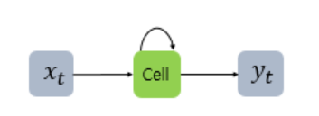

- x는 입력벡터, y는 출력벡터. 은닉층에서 활성화 함수를 통해 결과를 내보내는 역할을 하는 노드를 셀(Cell)이라고 함. 이전 값을 기억하려는 일종의 메모리 역할이므로, 메모리 셀 또는 RNN셀 이라고도 함.

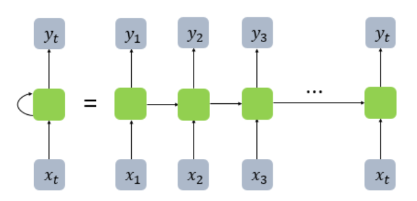

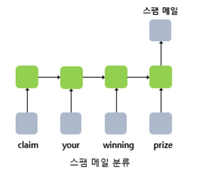

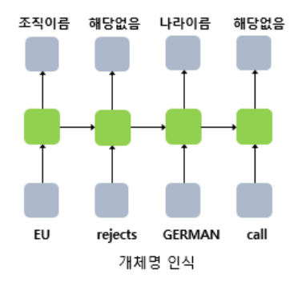

- RNN의 은닉층 h(t): 주로 하이퍼볼릭탄젠트(tanh)가 사용, ReLU를 사용하기도 함.

```python
# RNN 층을 추가하는 코드.
model.add(SimpleRNN(hidden_size)) # 가장 간단한 형태

# 추가 인자를 사용할 때
model.add(SimpleRNN(hidden_size, input_shape=(timesteps, input_dim)))

# 다른 표기
model.add(SimpleRNN(hidden_size, input_length=M, input_dim=N))
# 단, M과 N은 정수
```

```python
from keras.models import Sequential
from keras.layers import SimpleRNN
model = Sequential()
model.add(SimpleRNN(3, input_shape=(2,10)))
# model.add(SimpleRNN(3, input_length=2, input_dim=10))와 동일함.
model.summary()
```

```
Model: "sequential_4"
_________________________________________________________________
Layer (type)                 Output Shape              Param #
=================================================================
simple_rnn (SimpleRNN)       (None, 3)                 42
=================================================================
Total params: 42
Trainable params: 42
Non-trainable params: 0
_________________________________________________________________
```

```python
model = Sequential()
model.add(SimpleRNN(3, batch_input_shape=(8,2,10)))
model.summary()
```

```
Model: "sequential_5"
_________________________________________________________________
Layer (type)                 Output Shape              Param #
=================================================================
simple_rnn_1 (SimpleRNN)     (8, 3)                    42
=================================================================
Total params: 42
Trainable params: 42
Non-trainable params: 0
_________________________________________________________________
```